# Estimating the overdispersion in COVID-19 transmission using outbreak sizes outside China

### Akira Endo, Centre for the Mathematical Modelling of Infectious Diseases COVID-19 Working Group, Adam Kucharski, Sebastian Funk

## Background

A novel coronavirus disease (COVID-19) outbreak, which is considered to be associated with a market in Wuhan, China, is now affecting a number of countries worldwide ([Zhu et al.](https://doi.org/10.1056/NEJMoa2001017)). Substantial amount of human-to-human transmissions are being observed; the basic reproduction number $R_0$ (the average number of secondary transmissions caused by a single primary case) has been estimated around 2-3 ([Zhao et al.](https://doi.org/10.1016/j.ijid.2020.01.050)). More than 30 countries have observed confirmed cases of COVID-19. A few countries have already shifted from the containment phase to the mitigation phase, with a substantial number of locally acquired cases (including those whose epidemiological link is untraceable). On the other hand, there are countries where a number of imported cases were ascertained but not as many secondary cases as one might expect with an $R_0$ value of 2-3.

This suggests that not all symptomatic cases cause a secondary transmission, which was also suggested in the past coronavirus outbreaks (SARS/MERS). Such high variation in the distribution of the number of secondary transmissions, so-called superspreading events, is critical information in the epidemic control strategy ([Lloyd-Smith et al.](https://doi.org/10.1038/nature04153)). High overdispersion in the offspring distribution suggests that most cases do not contribute to the expansion of the epidemic, thereby highlighting the importance of containment efforts to prevent superspreading events from happening.

Here we estimate the amount of overdispersion, or superspreading, by using a mathematical model of transmission that is characterised $R_0$ and the overdispersion parameter $k$ of a negative binomial branching process. We fit this model to worldwide data on COVID-19 cases to estimate $k$ given the likely range of $R_0$ and interpret this in the context of superspreading.

## Method

Assume that the offspring distribution for COVID-19 cases is an i.i.d. negative-binomial distribution. The probability mass function for the final cluster size resulting from $s$ initial cases is, according to [Blumberg et al.](https://doi.org/10.1371/journal.ppat.1004452), given by $$ c(x;s)=P(X=x;s)=\frac{ks}{kx+x-s}\binom{kx+x-s}{x-s}\frac{\left(\frac{R_0} k\right)^{x-s}}{\left(1+\frac{R_0} k\right)^{kx+x-s}}. $$

If the observed case counts are part of an ongoing outbreak in a country, cluster sizes may grow in the future. To address this issue, we adjusted the likelihood corresponding those countries with ongoing outbreak by only using the condition that the final cluster size of such a country has to be larger than the currently observed number of cases. The corresponding likelihood function is $$ c_\mathrm{o}(x;s)=P(X\geq x;s)=1-\sum_{m=0}^{x}c(m;s)+c(x;s) $$

### Defining countries with ongoing outbreak and total likelihood

We assumed that the growth of a cluster in a country had ceased if 7 days are passed since the latest reported cases (denoted by $A$). We applied the final size likelihood $c(x;s)$ to those countries and $c_\mathrm{o}(x;s)$ to the rest of the countries (countries with ongoing outbreak: $B$).

The total likelihood is $$ L(R_0,k)=\prod_{i\in A}P(X=x_i;s_i)\prod_{i\in B}P(X\geq x_i;s_i) $$

### Data source

To distinguish between countries with and without an ongoing outbreak, we extracted daily case counts from an [online resource (COVID2019.app)](https://docs.google.com/spreadsheets/d/1Z7VQ5xlf3BaTx_LBBblsW4hLoGYWnZyog3jqsS9Dbgc) and determined the dates of the latest case confirmation for each country (as of 27 February).

```r
library(repr)
options(repr.plot.width=6, repr.plot.height=5)
# options(jupyter.plot_mimetypes = "image/svg+xml")
currdate=as.Date("2020-2-27")
# buffer period: we assume the growth of a cluster is ceased when this period has been passed since the latest case report
buffer=7
```

```r
# Data
# Imported and local cases outside China
# Source (accessed 4/3/2020): https://www.who.int/docs/default-source/coronaviruse/situation-reports/20200227-sitrep-38-covid-19.pdf
WHO_data=read.csv("../data/bycountries_27Feb2020.csv")
WHO_data[,"ImportedChina"]=WHO_data[,"ImportedChina"]+WHO_data[,"ImportedOthers"]
WHO_data=WHO_data[,-4]
colnames(WHO_data)[3]="Imported"
rownames(WHO_data)=WHO_data[,1]

# Daily confirmed cases (by date of confirmation)
# Source (accessed 18/2/2020): https://docs.google.com/spreadsheets/d/1Z7VQ5xlf3BaTx_LBBblsW4hLoGYWnZyog3jqsS9Dbgc
daily_data=read.csv("../data/dailycases_international_27Feb2020.csv")
countrynames=daily_data[-(1:3),2]
names(countrynames)=as.character(countrynames)
counts=suppressWarnings(apply(t(daily_data[-(1:2),-(1:2)]),1:2,as.numeric))
dates=as.Date("2020-1-13")+1:nrow(counts)-1
dailydata=cbind(dates,as.data.frame(counts))
dailydata=dailydata[,-2]
rownames(dailydata)=dailydata[,1]
colnames(dailydata)=c("date",as.character(countrynames))


# get dates of last reported case for each country
dateidx=seq(as.Date("2020-1-13"),currdate,by="days")
dailydata_tillcurrdate=dailydata[as.character(dateidx),-1]
latestdates=as.Date(apply(dailydata_tillcurrdate,2,function(x){
    lastreported=tail(which(!(x %in% NA)),1)
    if(length(lastreported)==0){NA}
    else{as.character(dailydata[lastreported,1])}
}))
latestdates=data.frame(countrynames,latestdates)
rownames(latestdates)=as.character(countrynames)

# get the number of cases within the buffer period
bufferdays=seq(currdate-buffer,currdate,by="days")
ongoingbranches=colSums(dailydata[as.character(bufferdays),-1],na.rm=T)

# reorder latestdates and ongoingbranches according to WHO data
latestdates_WHO=latestdates[rownames(WHO_data),2]
ongoingbranches_WHO=ongoingbranches[rownames(WHO_data)]
WHO_data=cbind(WHO_data,latestdate=latestdates_WHO,ongoingbranches=ongoingbranches_WHO)
WHO_data[,-1]
WHO_data=WHO_data[!rownames(WHO_data) %in% c("Egypt","Iran","Estonia"),] # exclude Egypt and Iran, where imported cases are reported to be zero
```

A data.frame: 46 × 7

|  | Total <int> | Imported <int> | Local <int> | Unknown <int> | Death <int> | latestdate <date> | ongoingbranches <dbl> |
| --- | --- | --- | --- | --- | --- | --- | --- |
| South Korea | 1766 | 17 | 605 | 1144 | 13 | 2020-02-27 | 1715 |
| Japan | 186 | 39 | 129 | 18 | 3 | 2020-02-27 | 112 |
| Singapore | 93 | 24 | 69 | 0 | 0 | 2020-02-27 | 12 |
| Australia | 23 | 20 | 3 | 0 | 0 | 2020-02-26 | 8 |
| Malaysia | 22 | 20 | 2 | 0 | 0 | 2020-02-27 | 1 |
| Vietnam | 16 | 8 | 8 | 0 | 0 | 2020-02-13 | 0 |
| Philippines | 3 | 3 | 0 | 0 | 1 | 2020-02-05 | 0 |
| Cambodia | 1 | 1 | 0 | 0 | 0 | 2020-01-30 | 0 |
| Thailand | 40 | 23 | 7 | 10 | 0 | 2020-02-26 | 5 |
| India | 3 | 3 | 0 | 0 | 0 | 2020-02-03 | 0 |
| Nepal | 1 | 1 | 0 | 0 | 0 | 2020-01-24 | 0 |
| Sri Lanka | 1 | 1 | 0 | 0 | 0 | 2020-01-27 | 0 |
| USA | 59 | 56 | 2 | 1 | 0 | 2020-02-26 | 45 |
| Canada | 11 | 9 | 1 | 1 | 0 | 2020-02-27 | 6 |
| Brazil | 1 | 1 | 0 | 0 | 0 | 2020-02-26 | 1 |
| Italy | 400 | 3 | 121 | 276 | 12 | 2020-02-27 | 647 |
| Germany | 21 | 3 | 14 | 4 | 0 | 2020-02-27 | 35 |
| France | 18 | 8 | 7 | 3 | 2 | 2020-02-27 | 26 |
| UK | 13 | 12 | 1 | 0 | 0 | 2020-02-27 | 7 |
| Spain | 12 | 10 | 1 | 1 | 0 | 2020-02-27 | 25 |
| Croatia | 3 | 2 | 1 | 0 | 0 | 2020-02-26 | 3 |
| Austria | 2 | 2 | 0 | 0 | 0 | 2020-02-27 | 5 |
| Finland | 2 | 2 | 0 | 0 | 0 | 2020-02-26 | 1 |
| Israel | 2 | 2 | 0 | 0 | 0 | 2020-02-27 | 3 |
| Russia | 2 | 2 | 0 | 0 | 0 | 2020-01-31 | 0 |
| Sweden | 2 | 2 | 0 | 0 | 0 | 2020-02-27 | 6 |
| Belgium | 1 | 1 | 0 | 0 | 0 | 2020-02-04 | 0 |
| Denmark | 1 | 1 | 0 | 0 | 0 | 2020-02-27 | 1 |
| Estonia | 1 | 0 | 0 | 1 | 0 | 2020-02-27 | 1 |
| Georgia | 1 | 1 | 0 | 0 | 0 | 2020-02-26 | 1 |
| Greece | 1 | 1 | 0 | 0 | 0 | 2020-02-27 | 3 |
| North Macedonia | 1 | 1 | 0 | 0 | 0 | 2020-02-26 | 1 |
| Norway | 1 | 1 | 0 | 0 | 0 | 2020-02-27 | 4 |
| Romania | 1 | 1 | 0 | 0 | 0 | 2020-02-26 | 1 |
| Switzerland | 1 | 1 | 0 | 0 | 0 | 2020-02-27 | 8 |
| Iran | 141 | 0 | 28 | 113 | 22 | 2020-02-27 | 243 |
| Kuwait | 43 | 43 | 0 | 0 | 0 | 2020-02-27 | 43 |
| Bahrain | 33 | 33 | 0 | 0 | 0 | 2020-02-26 | 33 |
| UAE | 13 | 8 | 5 | 0 | 0 | 2020-02-27 | 10 |
| Iraq | 6 | 6 | 0 | 0 | 0 | 2020-02-27 | 7 |
| Oman | 4 | 4 | 0 | 0 | 0 | 2020-02-27 | 6 |
| Lebanon | 1 | 1 | 0 | 0 | 0 | 2020-02-27 | 3 |
| Pakistan | 2 | 1 | 0 | 1 | 0 | 2020-02-26 | 2 |
| Afghanistan | 1 | 1 | 0 | 0 | 0 | 2020-02-24 | 1 |
| Egypt | 1 | 0 | 1 | 0 | 0 | 2020-02-14 | 0 |
| Algeria | 1 | 1 | 0 | 0 | 0 | 2020-02-25 | 1 |

```r
# label countries with/without cases in the last (buffer) days
isextinct=WHO_data$latestdate<currdate-buffer
icases=WHO_data$Imported
lcases=WHO_data$Local
ocases=WHO_data$ongoingbranches
```

```r
# cluster size inference
# for extinct clusters
library(VGAM)
library(matrixStats)
llextinct<-function(icases,lcases,R0,k,importcontrol=F){
    if(importcontrol){# For Sensitivity: different R0 for imported cases
        return(llextinct_importcontrol(icases,lcases,R0,k))
    }
    if(length(icases)==0)return(0)
    tcases=lcases+icases
    lls=log(k)+log(icases)-log((k+1)*tcases-icases)+lchoose((k+1)*tcases-icases,tcases-icases)+(tcases-icases)*(log(R0)-log(k))-((k+1)*tcases-icases)*log(1+R0/k)
    sum(lls,na.rm=T)
}

# only use the number as the lower bound of cluster size for ongoing countries
lltruncate<-function(icases,lcases,R0,k,importcontrol=F){
    if(length(icases)==0) return(0)
    ll=0
    for(i in 1:length(icases)){
        lprob=0
        if(icases[i]==0||lcases[i]==0)next
        for(x in 0:(lcases[i]-1)){
            lle=llextinct(icases[i],x,R0,k,importcontrol)
            if(lprob<lle){
                lprob=-Inf
                break
            }
            lprob=lprob+log1mexp(-(lle-lprob))
        }
        if(!is.nan(lprob))ll=ll+lprob
    }
    return(ll)
}

lltotal<-function(R0invk,icases,lcases,isextinct,importcontrol=F){
    R0=R0invk[1];k=1/R0invk[2]
    llextinct(icases[isextinct],lcases[isextinct],R0,k,importcontrol)+lltruncate(icases[!isextinct],lcases[!isextinct],R0,k,importcontrol)
}
lltotal_R0<-function(invk,icases,lcases,isextinct,R0,importcontrol=F){
    k=1/invk
    llextinct(icases[isextinct],lcases[isextinct],R0,k,importcontrol)+lltruncate(icases[!isextinct],lcases[!isextinct],R0,k,importcontrol)
}
```

```r
# Test block
R0=runif(100,0,5);k=runif(100,0,5)
# llextinct: equals negbinom when x==s
all.equal(dnbinom(0,k,mu=R0,log=T),sapply(1:length(R0),function(x){llextinct(1,0,R0[x],k[x])}))
# lltruncate: sum up to (almost) 1 when R0<<1
R0fix=runif(30)/2;k=runif(30,0,5)
lls=sapply(1:length(R0fix),function(x){lltruncate(sample(1:5,1),3e4,R0fix[x],k[x])})
all.equal(exp(lls),numeric(length(R0fix)))
```

TRUE

TRUE

## Results

### Overdispersion parameter

```r
# MCMC
library(LaplacesDemon)
Data=list(N=13,mon.names=c("R0","k"),parm.names="invk",R0=1,icases=icases,lcases=lcases,ocases=ocases,isextinct=isextinct)
Model=function(parm,Data){
    invk=interval(parm,0)
    lp=lltotal_R0(invk,Data$icases,Data$lcases,Data$isextinct,Data$R0)
    lp=lp+dnorm(invk,0,10,log=T)
    return(list(LP=lp,Dev=-2*lp,Monitor=c(Data$R0,1/invk),yhat=NULL,parm=invk))
}
R0s=1:20/4
niter=10000
set.seed(19)
mcmcfits=lapply(R0s,function(R0){
    Data$R0=R0
    fit=LaplacesDemon(Model=Model,Data=Data,Initial.Values=50,Covar=NULL,Iterations=niter,Status=niter,Thinning=10,Algorithm='HARM',Specs=list(alpha.star=0.2,B=NULL))
})

k_mcmc=sapply(mcmcfits,function(x){x$Monitor[(niter%/%20):(niter%/%10),2]})
ll_mcmc=sapply(mcmcfits,function(x){-x$Deviance[(niter%/%20):(niter%/%10)]/2})
```

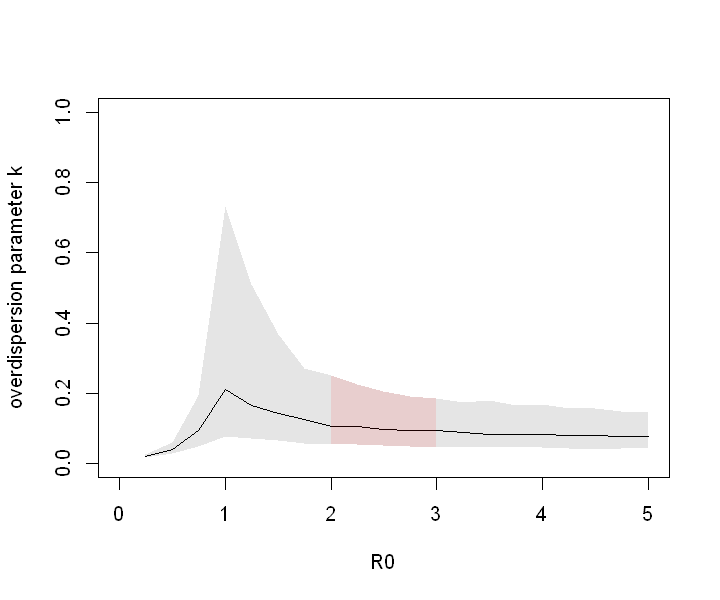

```r
# Plot
med=apply(k_mcmc,2,median)
cri=apply(k_mcmc,2,function(x){quantile(x,c(0.025,0.975))})
plot(x=R0s,y=med,xlim=c(0,5),ylim=c(0,1),type="l",xlab="R0",ylab="overdispersion parameter k")
polygon(x=c(R0s,rev(R0s)),y=c(cri[1,],rev(cri[2,])),lty=0,col=rgb(0,0,0,0.1))
polygon(x=c(seq(2,3,length.out=5),seq(3,2,length.out=5)),y=c(cri[1,8:12],cri[2,12:8]),lty=0,col=rgb(1,0,0,0.1))
```

### Proportion responsible for 80% of transmissions

Following [Grantz et al.](https://hopkinsidd.github.io/nCoV-Sandbox/DispersionExploration.html), we calculated the estimated proportion of infected individuals responsible for 80% of secondary transmissions caused. Such proportion $p_{80\%}$ is given as $$ 1-p_{80\%}=\int_0^{X}\mathrm{NB}\left(\lfloor x\rfloor;k,\frac{k}{R_0+k}\right)dx, $$ where $X$ satisfies $$ 1-0.8=\frac 1{R_0}\int_0^{X}\lfloor x\rfloor\mathrm{NB}\left(\lfloor x\rfloor;k,\frac{k}{R_0+k}\right)dx. $$

Note that $$ \frac 1{R_0}\int_0^{X}\lfloor x\rfloor\mathrm{NB}\left(\lfloor x\rfloor;k,\frac{k}{R_0+k}\right)dx=\int_0^{X-1}\mathrm{NB}\left(\lfloor x\rfloor;k+1,\frac{k}{R_0+k}\right)dx. $$

We computed $p_{80\%}$ for each MCMC sample to yield median and 95% CrIs.

```r
# Calculate proportion responsible for 80% of total transmissions
propresponsible=function(R0,k,prop){
    qm1=qnbinom(1-prop,k+1,mu=R0*(k+1)/k)
    remq=1-prop-pnbinom(qm1-1,k+1,mu=R0*(k+1)/k)
    remx=remq/dnbinom(qm1,k+1,mu=R0*(k+1)/k)
    q=qm1+1
    1-pnbinom(q-1,k,mu=R0)-dnbinom(q,k,mu=R0)*remx
}

# test
R0=runif(100,0,5);k=runif(100,0,5)
testprops=sapply(1:length(R0),function(x)propresponsible(R0[x],k[x],1))
all.equal(testprops,1-dnbinom(0,k,mu=R0)) # those generating at least one offspring are responsible for 100% of transmissions
```

TRUE

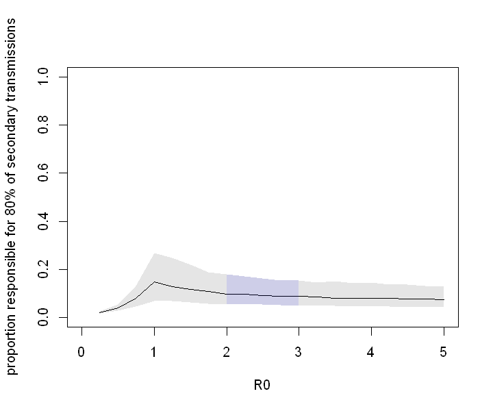

```r
props=sapply(1:length(R0s),function(R0id)sapply(k_mcmc[,R0id],function(k_)propresponsible(R0s[R0id],k_,0.8)))
med=apply(props,2,median)
cri=apply(props,2,function(x){quantile(x,c(0.025,0.975))})
plot(x=R0s,y=med,xlim=c(0,5),ylim=c(0,1),type="l",xlab="R0",ylab="proportion responsible for 80% of secondary transmissions")
polygon(x=c(R0s,rev(R0s)),y=c(cri[1,],rev(cri[2,])),lty=0,col=rgb(0,0,0,0.1))
polygon(x=c(seq(2,3,length.out=5),seq(3,2,length.out=5)),y=c(cri[1,8:12],cri[2,12:8]),lty=0,col=rgb(0,0,1,0.1))
```

### Joint estimation of $R_{0}$ and $k$

We performed a joint estimation of $R_0$ and $k$ by MCMC (with a weakly-informed normal prior $\mathcal N(\mu=3,\sigma=5)$ for $R_0$; the prior for $k^{-1}$ was the same as above). The posterior distribution indicated that the lower bound of $R_0$ may be 1.4 and the upper bound of $k$ may be 0.2. The upper bound of $R_0$ did not differ from that of the prior, suggesting that our model and data did not contain much information on the upper bound of $R_0$.

```r
# Joint estimation
Data_joint=list(N=13,mon.names=c("R0","k"),parm.names=c("R0","invk"),icases=icases,lcases=lcases,ocases=ocases,isextinct=isextinct)
Model_joint=function(parm,Data){
    parm=interval(parm,0)
    lp=lltotal(parm,Data$icases,Data$lcases,Data$isextinct)
    lp=lp+dnorm(parm[1],3,5,log=T)+dnorm(parm[2],0,10,log=T)
    return(list(LP=lp,Dev=-2*lp,Monitor=c(parm[1],1/parm[2]),yhat=NULL,parm=parm))
}
niter=10000
fit=LaplacesDemon(Model=Model_joint,Data=Data_joint,Initial.Values=c(1,1),Covar=NULL,Iterations=niter,Status=niter%/%10,Thinning=10,Algorithm='HARM',Specs=list(alpha.star=0.23,B=NULL))
```

A matrix: 2 × 7 of type dbl

|  | Mean | SD | MCSE | ESS | LB | Median | UB |
| --- | --- | --- | --- | --- | --- | --- | --- |
| R0 | 5.06506333 | 2.84184463 | 0.127371174 | 649.5488 | 1.40334350 | 4.40329657 | 11.5525352 |
| k | 0.09382923 | 0.04597227 | 0.002015266 | 631.5743 | 0.04355945 | 0.08145725 | 0.2088263 |

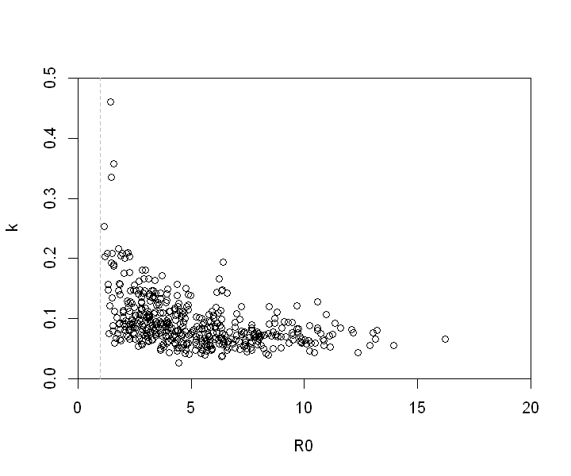

```r
plot(fit$Monitor[niter%/%20+1:(niter%/%20),1:2],xlim=c(0,20),ylim=c(0,0.5),yaxs="i",xaxs="i")
abline(v=1,col="grey",lty=2)
fit$Summary2[c("R0","k"),]
```

## Additional analysis

### Model comparison with a Poisson model

The baseline negative-binomial branching process model was compared with a Poisson branching process model by the widely-applicable Bayesian information criterion (WBIC).

```r
# model comparison with a Poisson model
Model_Pois=function(R0,Data){
    ret=Model_joint(c(R0,1e-10),Data)
    ret$parm=ret$parm[1]
    ret
}
Data_Pois=list(N=13,mon.names=c("R0","k"),parm.names="R0",icases=icases,lcases=lcases,ocases=ocases,isextinct=isextinct)

niter=10000
fit_Pois=LaplacesDemon(Model=Model_Pois,Data=Data_Pois,Initial.Values=2,Covar=NULL,Iterations=niter,Status=niter%/%10,Thinning=10,Algorithm='HARM',Specs=list(alpha.star=0.23,B=NULL))

fit_Pois=LaplacesDemon(Model=Model_Pois,Data=Data_Pois,Initial.Values=2,Covar=NULL,Iterations=niter,Status=niter%/%10,Thinning=10,Algorithm='HARM',Specs=list(alpha.star=0.23,B=NULL))
Model_joint_WBIC=function(parm,Data){
    ret=Model_joint(parm,Data)
    ret$LP=ret$LP/log(nrow(WHO_data))
    ret
}
Model_Pois_WBIC=function(parm,Data){
    ret=Model_Pois(parm,Data)
    ret$LP=ret$LP/log(nrow(WHO_data))
    ret
}
WBfit_joint=LaplacesDemon(Model=Model_joint_WBIC,Data=Data_joint,Initial.Values=2,Covar=NULL,Iterations=niter,Status=niter%/%10,Thinning=10,Algorithm='HARM',Specs=list(alpha.star=0.23,B=NULL))
WBfit_Pois=LaplacesDemon(Model=Model_Pois_WBIC,Data=Data_Pois,Initial.Values=2,Covar=NULL,Iterations=niter,Status=niter%/%10,Thinning=10,Algorithm='HARM',Specs=list(alpha.star=0.23,B=NULL))
print(list(WBIC.NBinom=WBfit_joint$Summary2["Deviance","Mean"],WBIC.Pois=WBfit_Pois$Summary2["Deviance","Mean"]))
```

[output not shown]

### Offspring distributions for different $R_0$ and $k$

Negative-binomial offspring distributions corresponding to $(R_0=2.5, k=0.1)$ and other sets of values

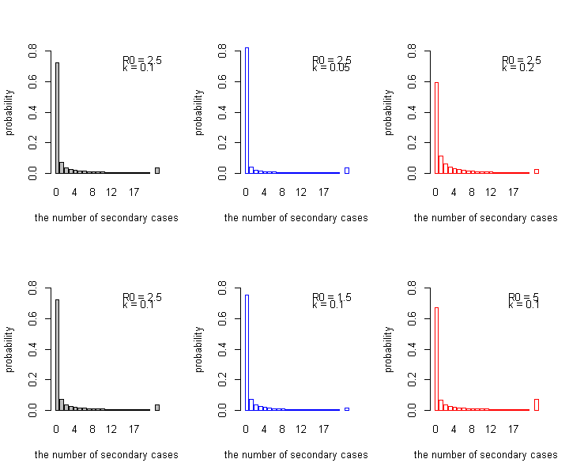

```r
# Show offspring distributions
par(mfrow=c(2,3))
barplot(c(dnbinom(0:20,0.1,mu=2.5),NA,pnbinom(20,0.1,mu=2.5,lower.tail=F)),names.arg=c(0:20,NA,">20"),xlab="the number of secondary cases",ylab="probability",ylim=c(0,0.8))
legend("topright",c("R0 = 2.5  ","k = 0.1  "),bty="n")
barplot(c(dnbinom(0:20,0.05,mu=2.5),NA,pnbinom(20,0.05,mu=2.5,lower.tail=F)),ylim=c(0,0.8),border="blue",col=NA,names.arg=c(0:20,NA,">20"),xlab="the number of secondary cases",ylab="probability")
legend("topright",c("R0 = 2.5  ","k = 0.05  "),bty="n")
barplot(c(dnbinom(0:20,0.2,mu=2.5),NA,pnbinom(20,0.2,mu=2.5,lower.tail=F)),ylim=c(0,0.8),border="red",col=NA,names.arg=c(0:20,NA,">20"),xlab="the number of secondary cases",ylab="probability")
legend("topright",c("R0 = 2.5  ","k = 0.2  "),bty="n")

barplot(c(dnbinom(0:20,0.1,mu=2.5),NA,pnbinom(20,0.1,mu=2.5,lower.tail=F)),names.arg=c(0:20,NA,">20"),xlab="the number of secondary cases",ylab="probability",ylim=c(0,0.8))
legend("topright",c("R0 = 2.5  ","k = 0.1  "),bty="n")
barplot(c(dnbinom(0:20,0.1,mu=1.5),NA,pnbinom(20,0.1,mu=1.5,lower.tail=F)),ylim=c(0,0.8),border="blue",col=NA,names.arg=c(0:20,NA,">20"),xlab="the number of secondary cases",ylab="probability")
legend("topright",c("R0 = 1.5  ","k = 0.1  "),bty="n")
barplot(c(dnbinom(0:20,0.1,mu=5),NA,pnbinom(20,0.1,mu=5,lower.tail=F)),ylim=c(0,0.8),border="red",col=NA,names.arg=c(0:20,NA,">20"),xlab="the number of secondary cases",ylab="probability")
legend("topright",c("R0 = 5  ","k = 0.1  "),bty="n")
```

## Smaller reproduction number for imported cases

Imported cases may exhibit a smaller reproduction number due to intervention measures such as isolation/quarantine. We accounted for this possibility by modifying the likelihood function $c(x;s)$ as $$ c_I(x;s)=\sum_{j=0}^x \operatorname{NB}(j;ks,\mu=sR_I)c(x-s;j). $$ where $R_I$ is the effective reproduction number for imported cases, which we varied (0.5, 0.8, 1.2) to estimate $k$. $R_0$ (the reproduction number for local cases) were assumed to be 2.5 throughout.

```r
llextinct_importcontrol<-function(icases,lcases,R0,k){
    if(length(icases)==0)return(0)
    tcases=lcases+icases
    lls=tcases*0
    for(i in 1:length(lls)){
        ls=sapply(0:lcases[i],function(ioffsprings){
            ll=dnbinom(ioffsprings,k*icases[i],mu=R0[1]*icases[i],log=T)+llextinct(ioffsprings,lcases[i]-ioffsprings,R0[2],k,F)
            return(ll)
        })
        lls[i]=lls[i]+logSumExp(ls)
    }
    sum(lls,na.rm=T)
}
```

```r
Data=list(N=13,mon.names=c("R0_imp","R0_loc","k"),parm.names="invk",R0=c(1,2.5),icases=icases,lcases=lcases,ocases=ocases,isextinct=isextinct)
Model=function(parm,Data){
    invk=interval(parm,0)
    lp=lltotal_R0(invk,Data$icases,Data$lcases,Data$isextinct,Data$R0,T)
    lp=lp+dnorm(invk,0,10,log=T)
    return(list(LP=lp,Dev=-2*lp,Monitor=c(Data$R0,1/invk),yhat=NULL,parm=invk))
}
R0s=c(0.5,0.8,1.2)
niter=10000
set.seed(20)
mcmcfits=lapply(R0s,function(R0){
    Data$R0[1]=R0
    fit=LaplacesDemon(Model=Model,Data=Data,Initial.Values=50,Covar=NULL,Iterations=niter,Status=niter,Thinning=10,Algorithm='HARM',Specs=list(alpha.star=0.2,B=NULL))
})

k_mcmc=sapply(mcmcfits,function(x){x$Monitor[(niter%/%20):(niter%/%10),3]})
ll_mcmc=sapply(mcmcfits,function(x){-x$Deviance[(niter%/%20):(niter%/%10)]/2})
```

```r
colnames(k_mcmc)=paste("k (R_I = ", c(0.5,0.8,1.2),")")
apply(k_mcmc,2,quantile,c(0.025,0.5,0.975))
```

A matrix: 3 × 3 of type dbl

|  | k (R_I = 0.5 ) | k (R_I = 0.8 ) | k (R_I = 1.2 ) |
| --- | --- | --- | --- |
| 2.5% | 0.09709496 | 0.07767332 | 0.06413361 |
| 50% | 0.29403301 | 0.17605994 | 0.13703123 |
| 97.5% | 1.23742522 | 0.53628262 | 0.31583619 |

### Simulation of underreporting

To investigate the effect of potential underreporting of cases, simulational dataset was generated and the overdispersion parameter $k$ was estimated by the maximum likelihood estimation. For each country in the WHO situation report dataset, the reporting probability $q_i$ was sampled from a beta distribution and the true number of imported cases were sampled based on the observed number and the sampled $q_i$. Three generations of transmission chains were drawn with a negative-binomial offspring distribution where $R_0=2.5$ and $k=0.1$ to provide the observed local cases given the same reporting probability $q_i$.

```r
R0=2.5;k=0.1
sim_data=function(icases,R0,k,betaparm=NULL){
    generations=numeric(length(icases))+3#sample(2:4,length(icases),T)+1
    if(is.null(betaparm)){reporting=numeric(length(icases))+1
    }else{reporting=rbeta(length(icases),betaparm[1],betaparm[2])}
    icases_all=rnbinom(length(icases),icases+1,reporting)+icases
    sapply(1:length(icases),function(i){sim_cluster(icases[i],icases_all[i],generations[i],reporting[i],R0,k)})
}
sim_cluster=function(icase,icase_all,generation,reporting,R0,k){
    recursive_nb=function(ts,generation,R0,k){
        if(length(ts)==generation){return(ts)}
        else if(ts[length(ts)]==0){
            return(c(ts,numeric(generation-length(ts))))
        }else{
            ts=c(ts,rnbinom(1,k*ts[length(ts)],k/(R0+k)))
            return(recursive_nb(ts,generation,R0,k))
        }
    }
    tseries=recursive_nb(icase_all,generation,R0,k)
    ts_obs=rbinom(length(tseries),tseries,reporting)
    c(icase,sum(ts_obs[-1]),ts_obs[length(ts_obs)]==0)
}
estim_k=function(times,R0,betaparm=NULL){
    sapply(1:times,function(x){
        data=sim_data(icases,R0,k,betaparm)
        ll=function(invk){-lltotal_R0(invk,data[1,],data[2,],as.logical(data[3,]),R0)}
        1/optim(fn=ll,par=10,method="Brent",lower=1e-2,upper=1e3)$par
    })
}

set.seed(20)
estims=sapply(c(8,5,2),function(x){estim_k(500,2.5,c(x,10-x))})
estims=cbind(estim_k(500,2.5),estims)
colnames(estims)=c("1 (constant)","beta(8,2)","beta(5,5)","beta(2,8)")
```

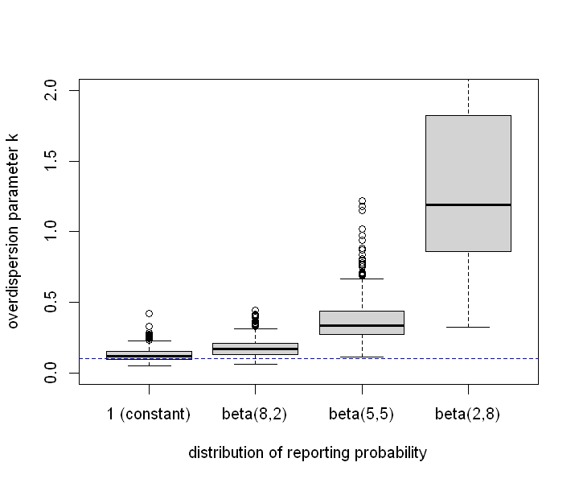

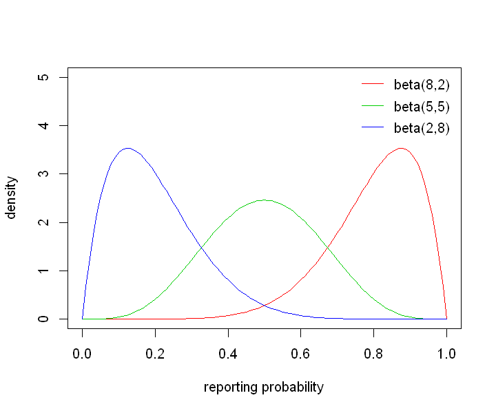

```r
# plot
boxplot(estims,ylim=c(0,2),col="lightgray",ylab="overdispersion parameter k",xlab="distribution of reporting probability")
abline(h=0.1,lty=2,col="blue")
betas=cbind(dbeta(0:100/100,8,2),dbeta(0:100/100,5,5),dbeta(0:100/100,2,8))
colnames(betas)=colnames(estims)[-1]
matplot(x=0:100/100,betas,type="l",ylim=c(0,5),lty=1,col=2:4,xlab="reporting probability",ylab="density")
legend("topright",col=2:4,legend=paste(colnames(betas),"   "),bty="n",lty=1,y.intersp=2)
```

The same procedure was repeated where the reporting probability for the imported cases was assumed to be 100%.

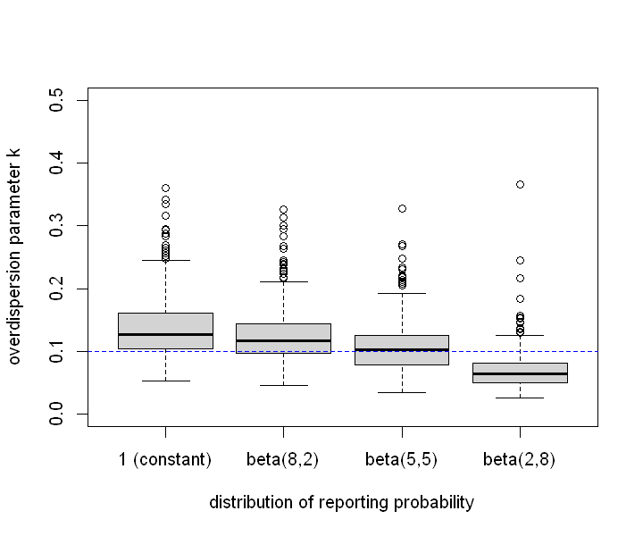

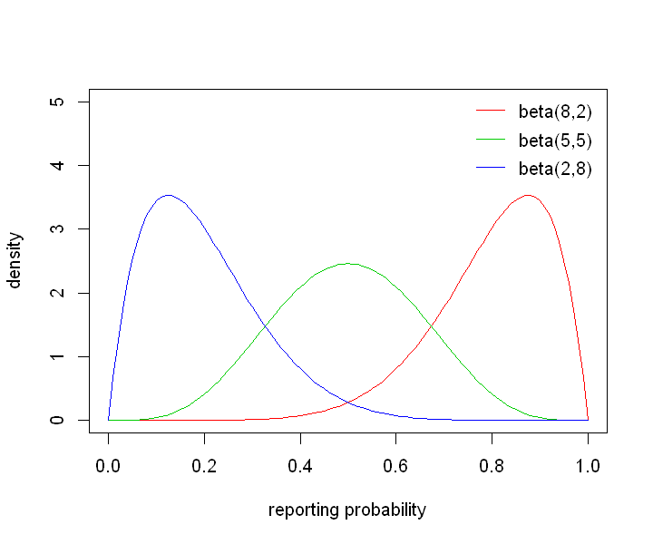

```r
# overwrite sim_data to assume 100% reporting for imported cases
sim_data=function(icases,R0,k,betaparm=NULL){
    generations=numeric(length(icases))+3#sample(2:4,length(icases),T)+1
    if(is.null(betaparm)){reporting=numeric(length(icases))+1
    }else{reporting=rbeta(length(icases),betaparm[1],betaparm[2])}
    icases_all=icases
    sapply(1:length(icases),function(i){sim_cluster(icases[i],icases_all[i],generations[i],reporting[i],R0,k)})
}
set.seed(19)
estims_all=sapply(c(8,5,2),function(x){estim_k(500,2.5,c(x,10-x))})
estims_all=cbind(estim_k(500,2.5),estims_all)
colnames(estims_all)=c("1 (constant)","beta(8,2)","beta(5,5)","beta(2,8)")

boxplot(estims_all,ylim=c(0,0.5),col="lightgray",ylab="overdispersion parameter k",xlab="distribution of reporting probability")
abline(h=0.1,lty=2,col="blue")
betas=cbind(dbeta(0:100/100,8,2),dbeta(0:100/100,5,5),dbeta(0:100/100,2,8))
colnames(betas)=colnames(estims)[-1]
matplot(x=0:100/100,betas,type="l",ylim=c(0,5),lty=1,col=2:4,xlab="reporting probability",ylab="density")
legend("topright",col=2:4,legend=paste(colnames(betas),"   "),bty="n",lty=1,y.intersp=2)
```